# Coding Assessment 1

Create a new `Quarto` file and copy the following statement into your new file. Then sign your name (by typing it) to the statement. Note that, in this and all future quizzes and assignments, full credit will not be given unless the statement and signature are present.

**Statement of Integrity**: “All work presented is my own, and I have followed all rules for collaboration. I have **not** used any AI for this assignment.”

**Important**: Remember to change your header so that the rendered `.html` file has all graphics and tables embedded within the file.

```
---
title: "Your Title"
author: "Your Name"
format:
  html:
    embed-resources: true
---
```

**Question 1** (4 points). Using the `diamonds` data set, create the following plot. For the first plot, you should change the default colour and fill of your histogram to values other than the default, but they do not need to match the colorus given below exactly.

```r
library(tidyverse)
diamonds
```

```
# A tibble: 53,940 × 10
   carat cut       color clarity depth table price     x     y     z
   <dbl> <ord>     <ord> <ord>   <dbl> <dbl> <int> <dbl> <dbl> <dbl>
 1  0.23 Ideal     E     SI2      61.5    55   326  3.95  3.98  2.43
 2  0.21 Premium   E     SI1      59.8    61   326  3.89  3.84  2.31
 3  0.23 Good      E     VS1      56.9    65   327  4.05  4.07  2.31
 4  0.29 Premium   I     VS2      62.4    58   334  4.2   4.23  2.63
 5  0.31 Good      J     SI2      63.3    58   335  4.34  4.35  2.75
 6  0.24 Very Good J     VVS2     62.8    57   336  3.94  3.96  2.48
 7  0.24 Very Good I     VVS1     62.3    57   336  3.95  3.98  2.47
 8  0.26 Very Good H     SI1      61.9    55   337  4.07  4.11  2.53
 9  0.22 Fair      E     VS2      65.1    61   337  3.87  3.78  2.49
10  0.23 Very Good H     VS1      59.4    61   338  4     4.05  2.39
# ℹ 53,930 more rows
```

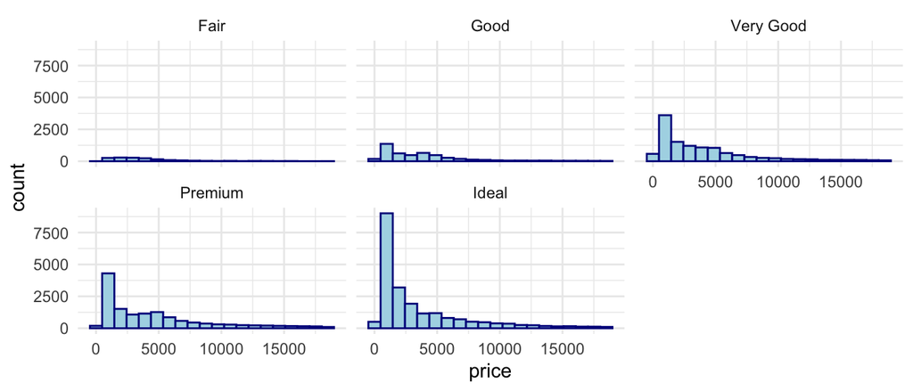

**Question 2** (4 points). Change **2** theme options of your plot in the previous question. At least one of these changes should involve the use of either `element_rect()` or `element_line()` in some way. The following gives the reference page we used in class: https://ggplot2.tidyverse.org/reference/theme.html

**Question 3** (2 points). Push your `.qmd` file to your GitHub repository. For this question, give the link to your GitHub repository here.